# Chapter 7: Applied Exercise 9

By: Neil Patel, Ziwei Yu, Kenzie Reed, Ivan Kirshin

## Applied Exercise 9

### Data

Load the Boston dataset and do a brief overview of the data to check for missing values.

```r
set.seed(24)
library(MASS)
attach(Boston)
head(Boston)
```

```
##      crim zn indus chas   nox    rm  age    dis rad tax ptratio  black
## 1 0.00632 18  2.31    0 0.538 6.575 65.2 4.0900   1 296    15.3 396.90
## 2 0.02731  0  7.07    0 0.469 6.421 78.9 4.9671   2 242    17.8 396.90
## 3 0.02729  0  7.07    0 0.469 7.185 61.1 4.9671   2 242    17.8 392.83
## 4 0.03237  0  2.18    0 0.458 6.998 45.8 6.0622   3 222    18.7 394.63
## 5 0.06905  0  2.18    0 0.458 7.147 54.2 6.0622   3 222    18.7 396.90
## 6 0.02985  0  2.18    0 0.458 6.430 58.7 6.0622   3 222    18.7 394.12
##   lstat medv
## 1  4.98 24.0
## 2  9.14 21.6
## 3  4.03 34.7
## 4  2.94 33.4
## 5  5.33 36.2
## 6  5.21 28.7
```

```r
summary(Boston)
```

```
##       crim                zn             indus            chas
##  Min.   : 0.00632   Min.   :  0.00   Min.   : 0.46   Min.   :0.00000
##  1st Qu.: 0.08204   1st Qu.:  0.00   1st Qu.: 5.19   1st Qu.:0.00000
##  Median : 0.25651   Median :  0.00   Median : 9.69   Median :0.00000
##  Mean   : 3.61352   Mean   : 11.36   Mean   :11.14   Mean   :0.06917
##  3rd Qu.: 3.67708   3rd Qu.: 12.50   3rd Qu.:18.10   3rd Qu.:0.00000
##  Max.   :88.97620   Max.   :100.00   Max.   :27.74   Max.   :1.00000
##       nox               rm             age              dis
##  Min.   :0.3850   Min.   :3.561   Min.   :  2.90   Min.   : 1.130
##  1st Qu.:0.4490   1st Qu.:5.886   1st Qu.: 45.02   1st Qu.: 2.100
##  Median :0.5380   Median :6.208   Median : 77.50   Median : 3.207
##  Mean   :0.5547   Mean   :6.285   Mean   : 68.57   Mean   : 3.795
##  3rd Qu.:0.6240   3rd Qu.:6.623   3rd Qu.: 94.08   3rd Qu.: 5.188
##  Max.   :0.8710   Max.   :8.780   Max.   :100.00   Max.   :12.127
##       rad              tax           ptratio          black
##  Min.   : 1.000   Min.   :187.0   Min.   :12.60   Min.   :  0.32
##  1st Qu.: 4.000   1st Qu.:279.0   1st Qu.:17.40   1st Qu.:375.38
##  Median : 5.000   Median :330.0   Median :19.05   Median :391.44
##  Mean   : 9.549   Mean   :408.2   Mean   :18.46   Mean   :356.67
##  3rd Qu.:24.000   3rd Qu.:666.0   3rd Qu.:20.20   3rd Qu.:396.23
##  Max.   :24.000   Max.   :711.0   Max.   :22.00   Max.   :396.90
##      lstat            medv
##  Min.   : 1.73   Min.   : 5.00
##  1st Qu.: 6.95   1st Qu.:17.02
##  Median :11.36   Median :21.20
##  Mean   :12.65   Mean   :22.53
##  3rd Qu.:16.95   3rd Qu.:25.00
##  Max.   :37.97   Max.   :50.00
```

### a

Summary shows that all polynomial terms are significant while predicting nox using using the poly function.

```r
lm.fit = lm(nox~poly(dis, 3), data=Boston)
summary(lm.fit)
```

```
##
## Call:
## lm(formula = nox ~ poly(dis, 3), data = Boston)
##
## Residuals:
##       Min        1Q    Median        3Q       Max
## -0.121130 -0.040619 -0.009738  0.023385  0.194904
##
## Coefficients:
##                Estimate Std. Error t value Pr(>|t|)
## (Intercept)    0.554695   0.002759 201.021  < 2e-16 ***
## poly(dis, 3)1 -2.003096   0.062071 -32.271  < 2e-16 ***
## poly(dis, 3)2  0.856330   0.062071  13.796  < 2e-16 ***
## poly(dis, 3)3 -0.318049   0.062071  -5.124 4.27e-07 ***
## ---
## Signif. codes:  0 '***' 0.001 '**' 0.01 '*' 0.05 '.' 0.1 ' ' 1
##
## Residual standard error: 0.06207 on 502 degrees of freedom
## Multiple R-squared:  0.7148, Adjusted R-squared:  0.7131
## F-statistic: 419.3 on 3 and 502 DF,  p-value: < 2.2e-16
```

The code below creates a range of values for the X’s. Then generates predictions using the predict function and based on the polynomial fit generated earlier. The results are then plotted. The plot below shows a smoothing curve fitting the data fairly well.

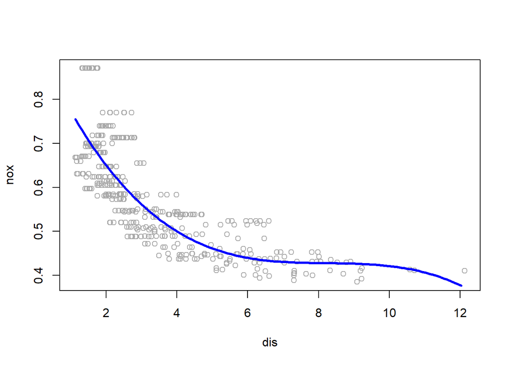

```r
dislim = range(dis)
dis.grid = seq(from=dislim[1], to=dislim[2], by=0.1)
lm.pred = predict(lm.fit, list(dis=dis.grid))
plot(nox~dis, data=Boston, col="darkgrey")
lines(dis.grid, lm.pred, col="blue", lwd=3)
```

### b

Here we are observing how the train MSE behaves as we increase the degree of the polynomial. So we plot polynomials of degrees 1 to 10 and save train RSS.

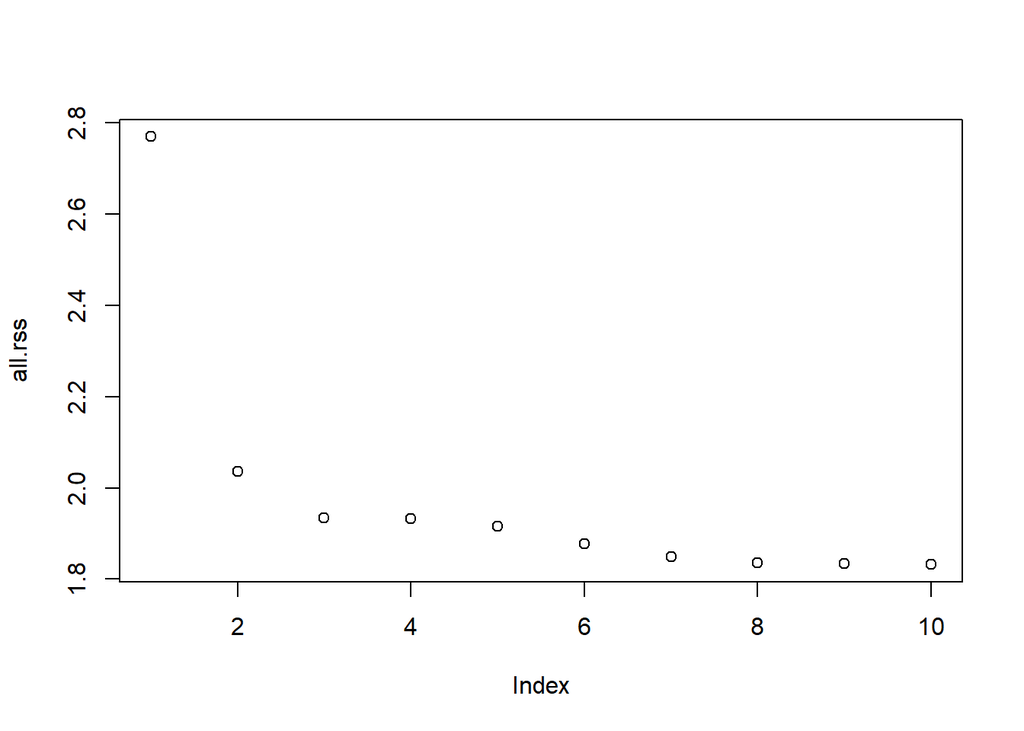

```r
all.rss = rep(NA, 10)
for (i in 1:10) {
  lm.fit = lm(nox~poly(dis, i), data=Boston)
  all.rss[i] = sum(lm.fit$residuals^2)
}
plot(all.rss)
```

As expected, train RSS decreases as the degree of polynomial increases. That is the train error rate decreases as flexibility in the model increases.

### c

We use 10-fold cross validation to find the best polynomial degree.

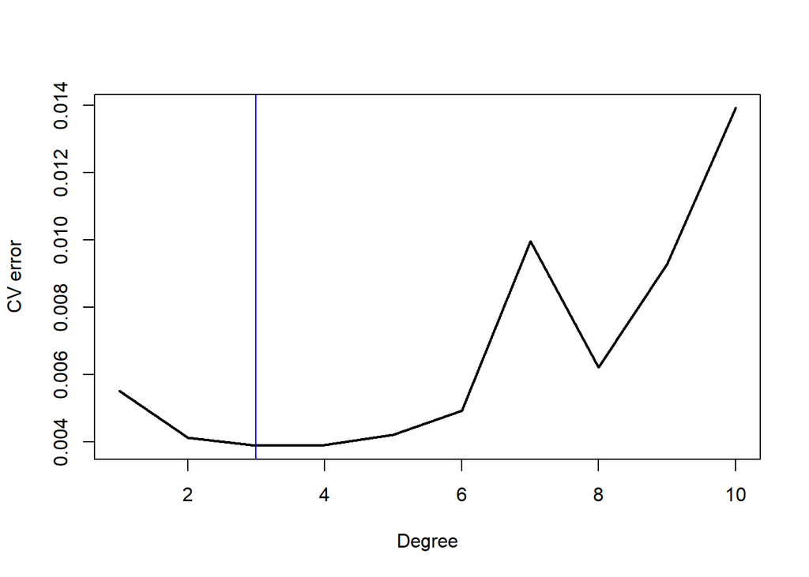

```r
library(boot)
all.deltas = rep(NA, 10)
for (i in 1:10) {
  glm.fit = glm(nox~poly(dis, i), data=Boston)
  all.deltas[i] = cv.glm(Boston, glm.fit, K=10)$delta[2]
}
plot(1:10, all.deltas, xlab="Degree", ylab="CV error", type="l", pch=20, lwd=2)
abline(v = which.min(all.deltas), col = "blue")
```

### d

We see that dis has a range from 1 to 13. Therefore, we split this range in roughly equal 4 intervals and establish knots at $[3, 6, 9]$. If the bs function is given degrees of freedom then knots are automatically determined by R.

```r
library(splines)
sp.fit = lm(nox~bs(dis, df=4, knots=c(3, 6, 9)), data=Boston)
summary(sp.fit)
```

```
##
## Call:
## lm(formula = nox ~ bs(dis, df = 4, knots = c(3, 6, 9)), data = Boston)
##
## Residuals:
##       Min        1Q    Median        3Q       Max
## -0.132134 -0.039466 -0.009042  0.025344  0.187258
##
## Coefficients:
##                                       Estimate Std. Error t value Pr(>|t|)
## (Intercept)                           0.709144   0.016099  44.049  < 2e-16
## bs(dis, df = 4, knots = c(3, 6, 9))1  0.006631   0.025467   0.260    0.795
## bs(dis, df = 4, knots = c(3, 6, 9))2 -0.258296   0.017759 -14.544  < 2e-16
## bs(dis, df = 4, knots = c(3, 6, 9))3 -0.233326   0.027248  -8.563  < 2e-16
## bs(dis, df = 4, knots = c(3, 6, 9))4 -0.336530   0.032140 -10.471  < 2e-16
## bs(dis, df = 4, knots = c(3, 6, 9))5 -0.269575   0.058799  -4.585 5.75e-06
## bs(dis, df = 4, knots = c(3, 6, 9))6 -0.303386   0.062631  -4.844 1.70e-06
##
## (Intercept)                          ***
## bs(dis, df = 4, knots = c(3, 6, 9))1
## bs(dis, df = 4, knots = c(3, 6, 9))2 ***
## bs(dis, df = 4, knots = c(3, 6, 9))3 ***
## bs(dis, df = 4, knots = c(3, 6, 9))4 ***
## bs(dis, df = 4, knots = c(3, 6, 9))5 ***
## bs(dis, df = 4, knots = c(3, 6, 9))6 ***
## ---
## Signif. codes:  0 '***' 0.001 '**' 0.01 '*' 0.05 '.' 0.1 ' ' 1
##
## Residual standard error: 0.0612 on 499 degrees of freedom
## Multiple R-squared:  0.7244, Adjusted R-squared:  0.7211
## F-statistic: 218.6 on 6 and 499 DF,  p-value: < 2.2e-16
```

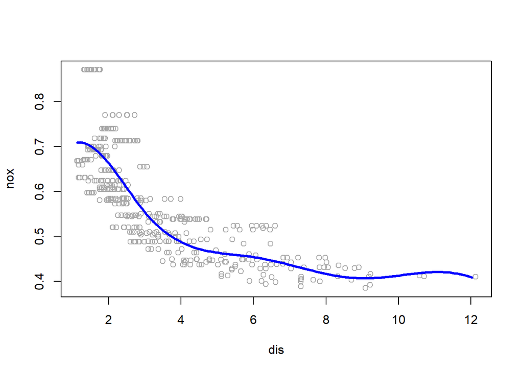

```r
sp.pred = predict(sp.fit, list(dis=dis.grid))
plot(nox~dis, data=Boston, col="darkgrey")
lines(dis.grid, sp.pred, col="blue", lwd=3)
```

The summary shows that all terms in spline fit are significant, except the first one. Plot shows that the spline fits data well.

### e

We fit regression splines with dfs between 3 and 20.

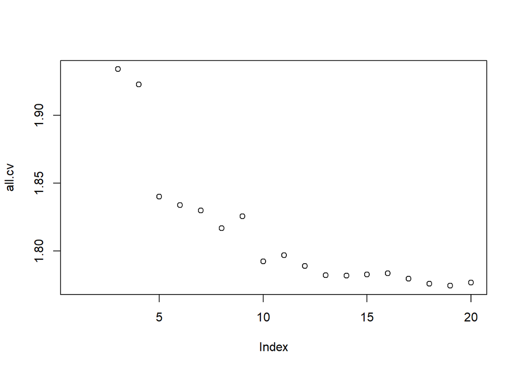

```r
all.cv = rep(NA, 20)
for (i in 3:20) {
  lm.fit = lm(nox~bs(dis, df=i), data=Boston)
  all.cv[i] = sum(lm.fit$residuals^2)
}
plot(all.cv)
```

Train RSS decreases, as expected, as the degrees of freedom (flexibility) increases.

### f

Finally, we use a 10-fold cross validation to find best df. We try all integer values of df between 3 and 20. You start with three degrees of freedom because one degree of freedom would just be an intercept, and two would just be a linear model.

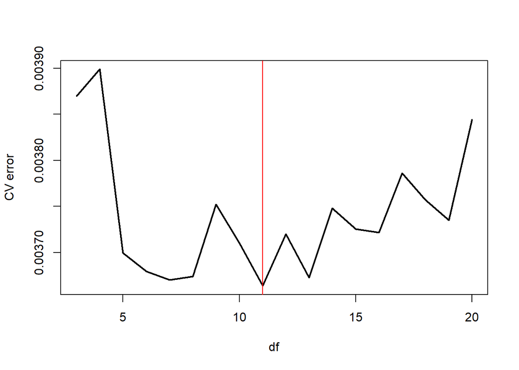

```r
all.cv = rep(NA, 20)
for (i in 3:20) {
  lm.fit = glm(nox~bs(dis, df=i), data=Boston)
  all.cv[i] = cv.glm(Boston, lm.fit, K=10)$delta[2]
}
plot(3:20, all.cv[-c(1, 2)], lwd=2, type="l", xlab="df", ylab="CV error")
abline(v = which.min(all.cv), col = "red")
```